# Lecture Notes for RMarkdown

By default we start in “Markdown” mode. Markdown lets us structure documents:

# Title

## Main Section

### Subsection

We can add various inline styling: *italics*, **bold**, `monospace fonts`.

- Lists/bullets
- [links](http://www.wikipedia.org)
- Quotes

> This is a quoted section.

```
Large verbatim
  bits of text
    can be formatted
      using backticks.
```

## Math Notation

There is also a built in system for writing mathematical expressions. For example, $x^2$.

You can also write “display” math like:

$$f(x) = \sin(\theta x)$$

or

$$g(x, y) = \frac{x + y}{2}$$

Various special symbols and operators have a backslash notation. Curly braces are used instead of parethenses to indicate arguments.

$$\int_{-\infty}^\infty f(x) \, dx = 1$$
This languae is also known at LaTeX (“lah-tech”) math notation. A really useful website is [Detexify](http://detexify.kirelabs.org/classify.html) (only use “mathmode” symbols).

Often times you want to have several lines that connect together. You can use the `aligned` environment:

$$\begin{aligned}
f(x) &= x^2 + 2xy + y^2 \\
&= (x + y)^2
\end{aligned}$$

There are some additional references in this week’s homework. Piazza will be a great place to share tips and tricks.

## Integrating R

When “knit”, RMarkdown will process all the R code included and insert the results into the document (processes from top to bottom, errors stop processing.)

To start an R code block add `{r}` after three backticks:

```r
# this is a comment in R, will be ignored by R
print("hello")
```

```
## [1] "hello"
```

You can also run code in your interpreter using Cmd-Return/Alt-Return.

Expressions are evaluated and results printed out by default:

```r
7 + 2
```

```
## [1] 9
```

```r
mean(rnorm(10))
```

```
## [1] -0.07839326
```

It is also possible to give additional instructions to the R “chunk”:

```r
stop("This would halt the knitting if it ran")
```

But notice it does display.

We can selectively hide the output of chunks, while keeping the code.

```r
2 + 3 # will not display
```

Sometimes you want to suppress the code itself (`echo = FALSE`).

```
## [1] "Surprise!"
```

To combine both hiding code and output (but still executing):

```r
print(hidden_var)
```

```
## [1] 7
```

For long calculations it can be useful to set `cache = TRUE` (just be careful if the cached chunk depends on other code or data that changes!)

```r
sum(1:1e10)
```

```
## [1] 5e+19
```

Inline results can be included using (backtick)r EXP (backtick). For example the sum of 3 and 4 is 7.

```r
estimate_of_mean <- 87.2
```

We estimate the mean as 87.2.

### Plotting

Let’s simulate the class linear model (will cover simulation much more soon).

```r
n <- 100 # number of units in the study
x <- runif(100, 10, 100)
y <- 2 + 0.1 * x + rnorm(n, mean = 0, sd = 4) ## generates
xy <- data.frame(x = x,  y = y) # column "x" gets values in variable x
```

We’ll emphasize the `ggplot2` library throughout the course. General strategy, map your columns to names (such as “x” and “y”) and then add additional elements to the plot.

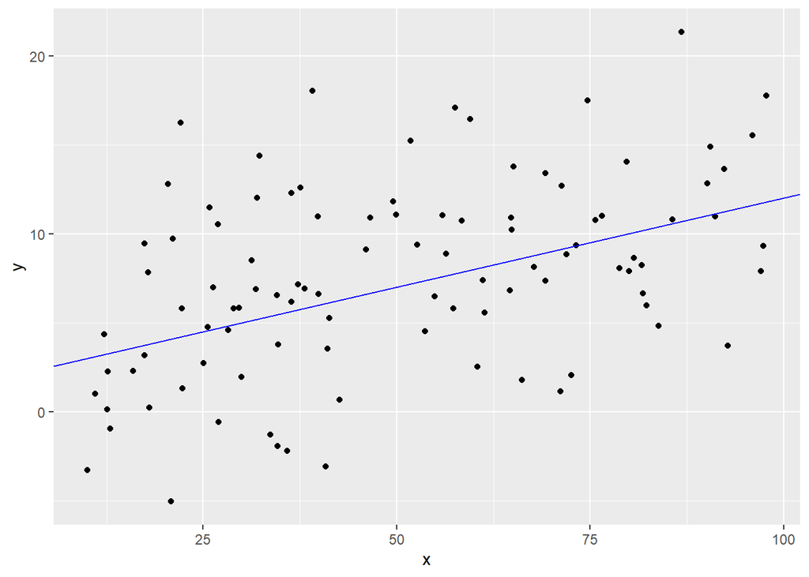

```r
library(ggplot2)
ggplot(data = xy, aes(x = x, y = y)) + geom_point() + geom_abline(intercept = 2, slope = 0.1, color = "blue")
```

Sometimes tables are more helpful than plots. The `knitr` package provides a nice table formatting function:

```r
library(knitr)
kable(xy[1:5, ]) # first 5 rows of the xy table
```

| x | y |
| --- | --- |
| 58.43996 | 10.733759 |
| 53.69371 | 4.537624 |
| 12.97902 | -0.922630 |
| 34.67865 | 3.774927 |
| 85.60337 | 10.816031 |

## RStudio Tools

### Getting Help

You can search the help in the left hand pane or interactively using

```
?t.test
??"Student"
```

Several useful “Cheatsheets” under `Help` menu.

### External Packages

We will frequently use the following packages:

```r
library(tidyverse)
```

Other packages in the `Packages` pane.

### Sessions and Environment

The `Console` pane contains a live R session. Session menu can

- Restart the session
- Set the working directory (makes it easier to load and save files)

The `Environment` pane shows useful information about the current session.

Example:

```r
random_letters <- sample(letters, size = 20, replace = TRUE)
```

### Debugging

If you RMarkdown document fails on a given R chunk, it can be useful to `Run all chunks above` then step through the code:

```r
xy <- mutate(xy, z = x + y) # this depends on xy, so we need to get that from a previous chunk
mean_x <- mean(xy$x)
```

R has a built in debugger as well, but this only works in pure .R scripts, not RMarkdown documents.